# Tarea: Peak-calling choices

#### Enriquecimiento

Figura 3.1.1

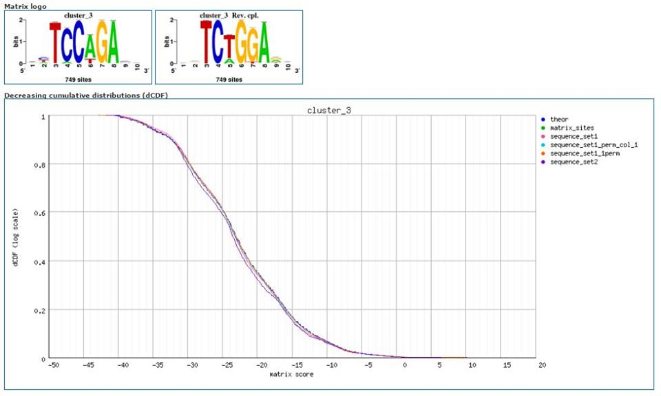

Figura 3.1.2

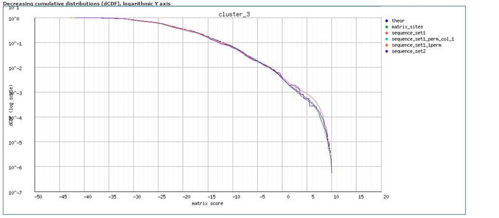

Figura 3.2.1

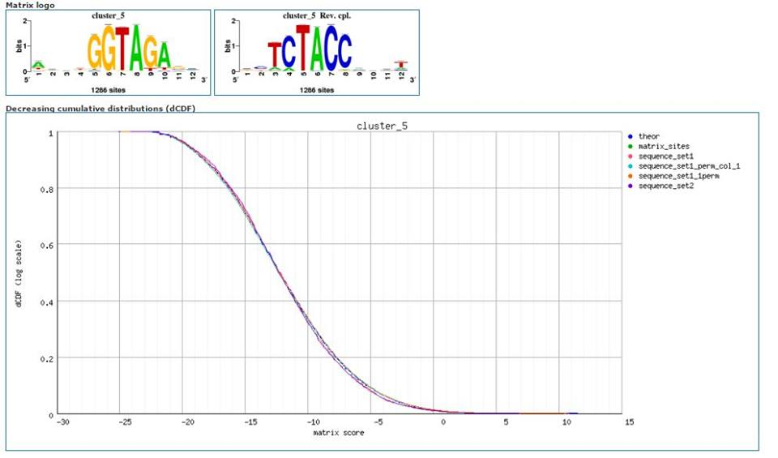

Figura 3.2.2

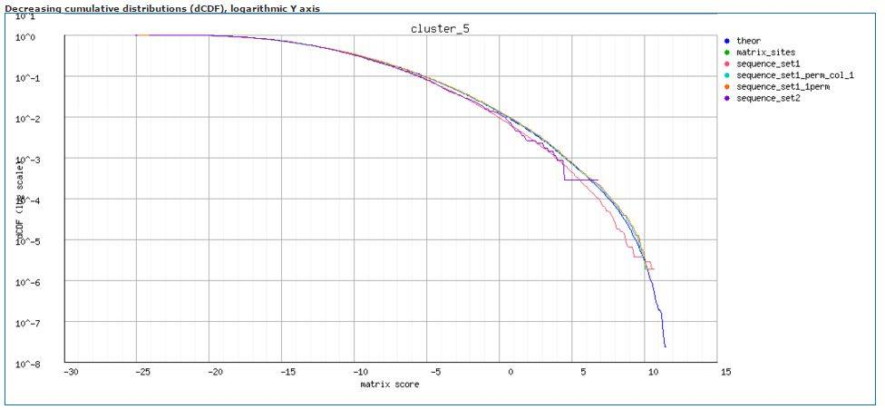

Figura 3.3.1

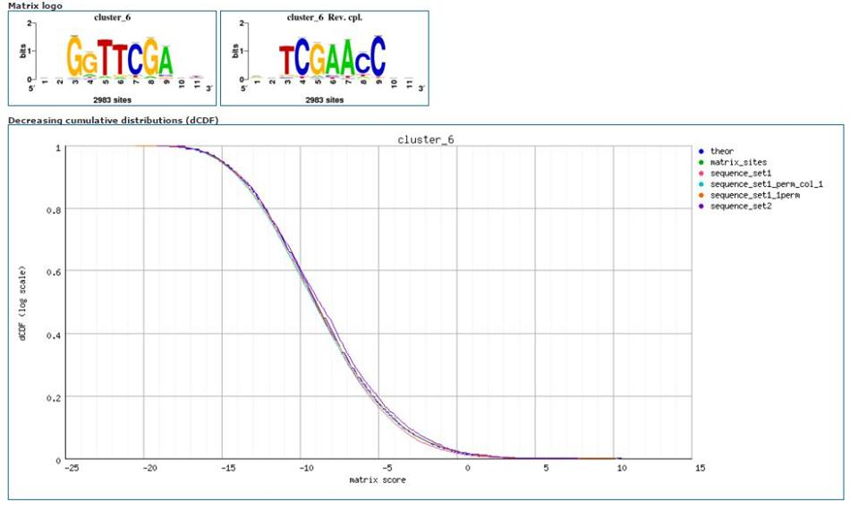

Figura 3.3.2

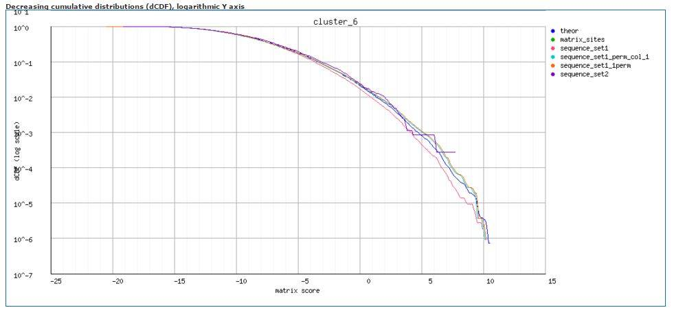

Figura 3.4.1

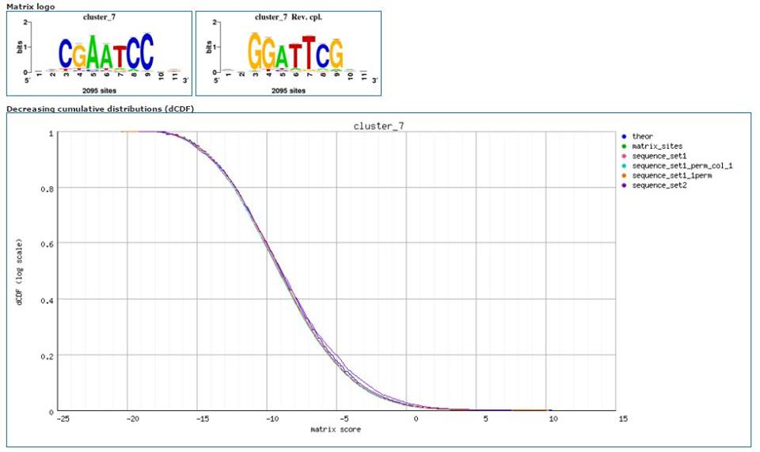

Figura 3.4.2

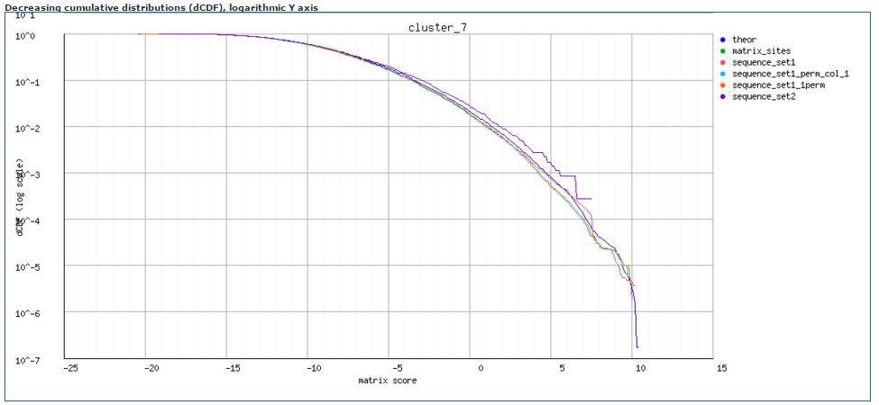

Figura 3.5.1

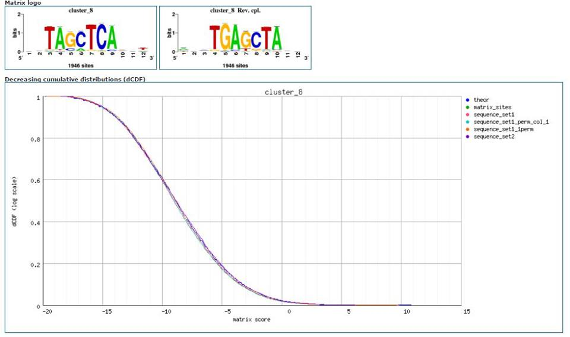

Figura 3.5.2

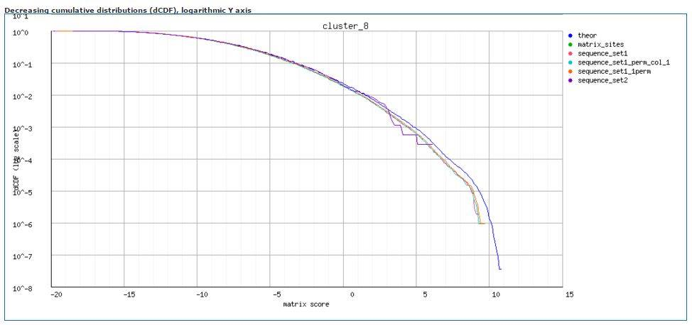

Figura 3.6.1

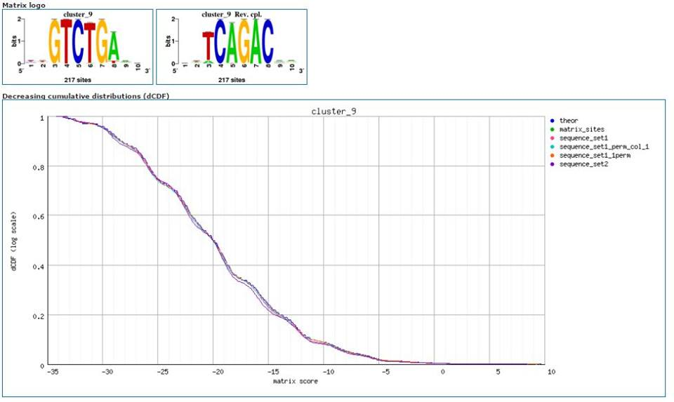

Figura 3.6.2

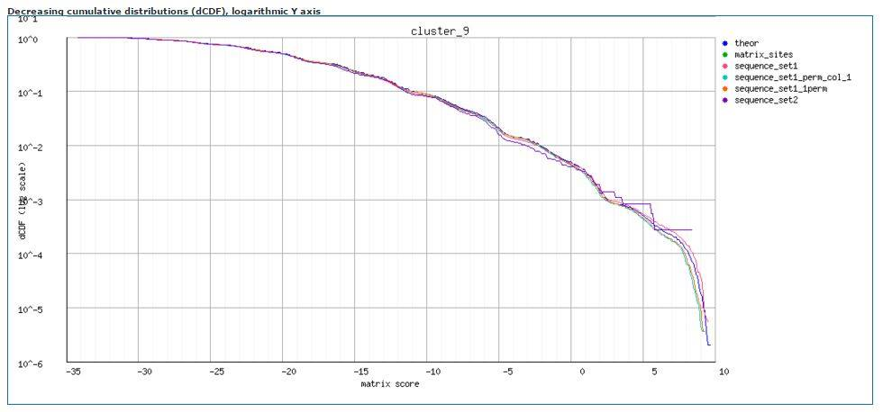

Figura 3.7.1

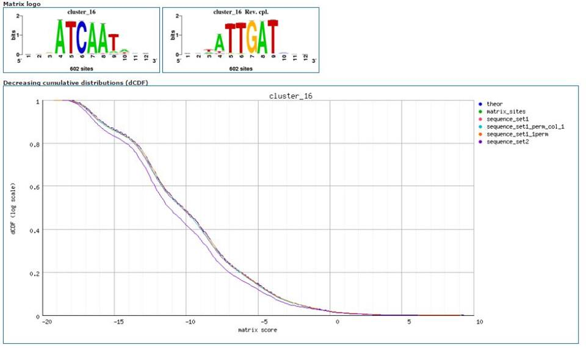

Figura 3.7.2

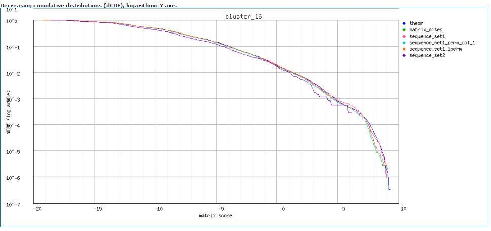

Figura 3.8.1

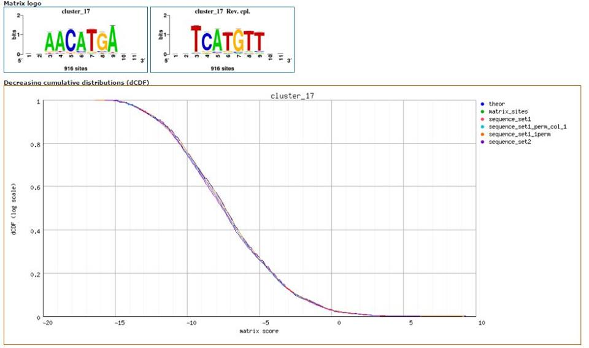

Figura 3.8.2

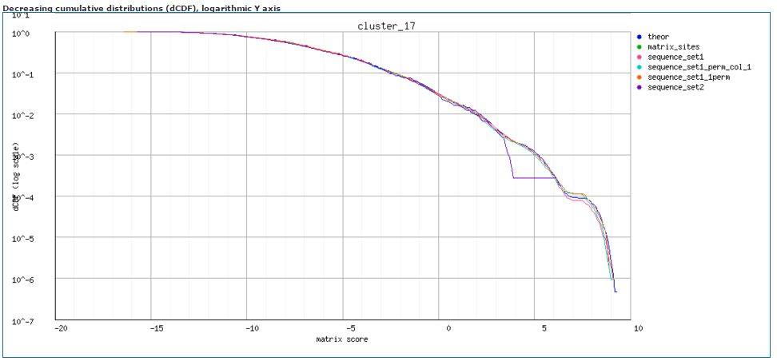

Figura 3.9.1

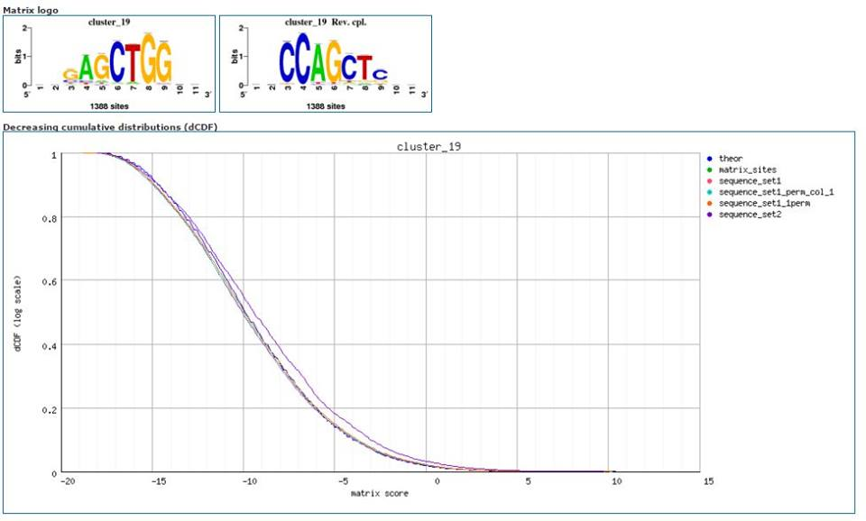

Figura 3.9.2

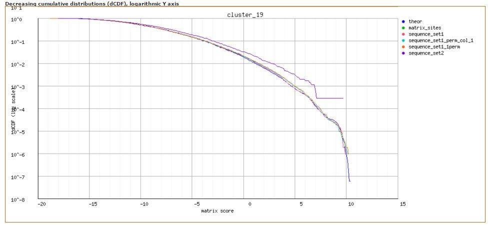

Figura 3.10.1

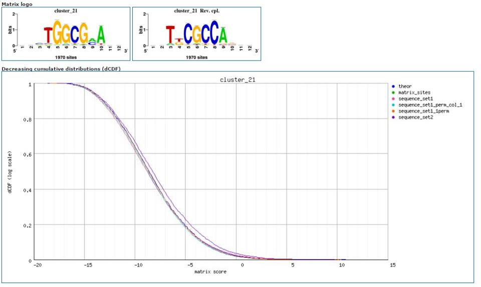

Figura 3.10.2

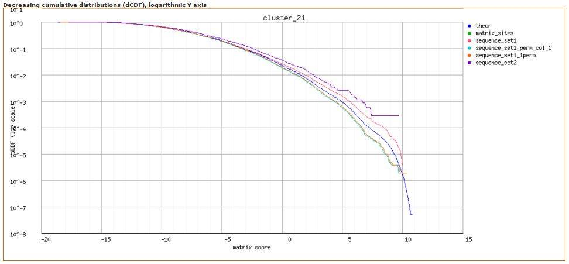

Figura 3.11.1

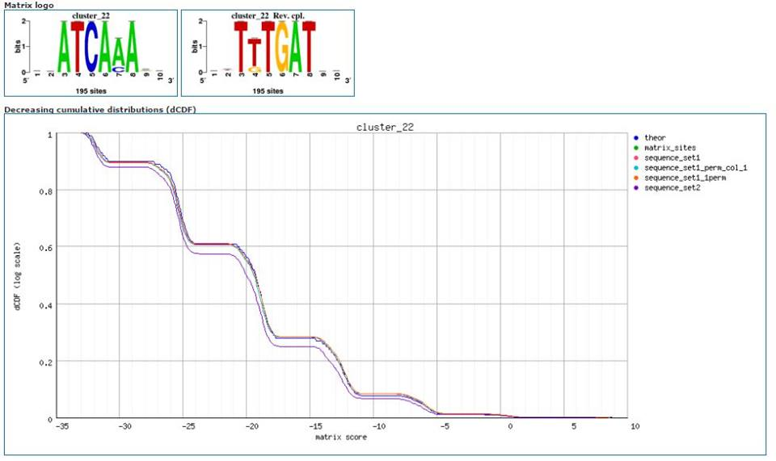

Figura 3.11.2

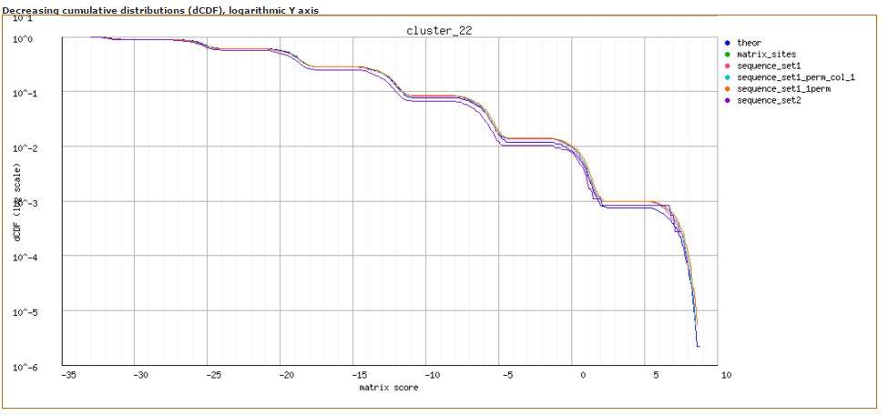

Figura 3.12.1

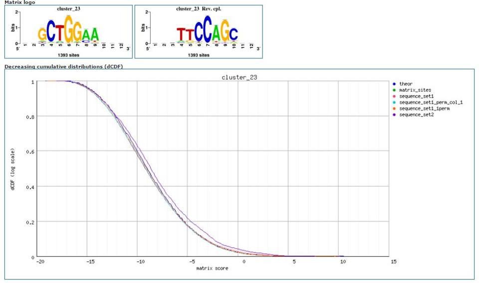

Figura 3.12.2

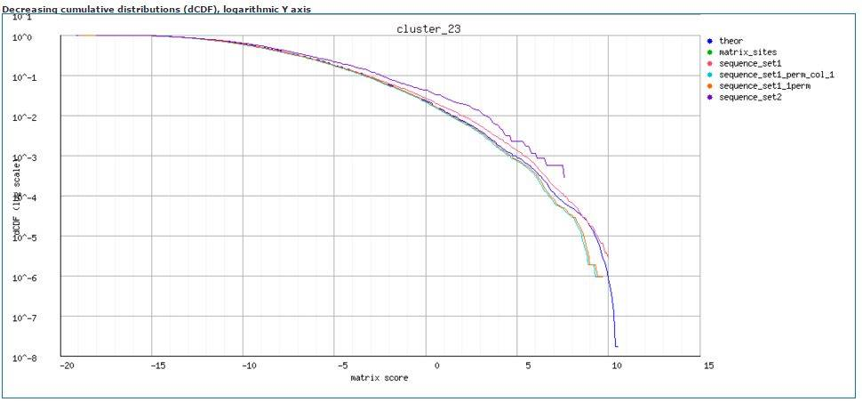

#### Golden standard

Figura 4.1

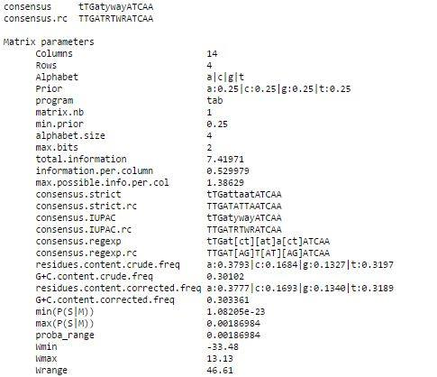

Figura 4.2

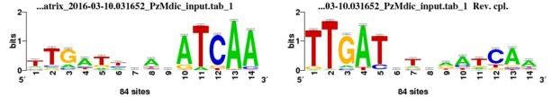

#### Referencias

<sup>[1]</sup> J Castro-Mondragon, C Rioualen, B Contreras-Moreira, J van Helden (2016) [RSAT::Plants: motif discovery in ChIP-seq peaks of plant genomes](http://cursos.lcg.unam.mx/claroline/document/goto/?url=%2FJacques_van-Helden_BEII_2016%2FRSAT_protocols_for_students_only%2Fchapter_RSAT_plant_ChIP-seq_motifs.html&cidReq=BE2_2016#data-sources).

<sup>[2]</sup> Illumina. [Precise analysis of DNA-protein binding sequences: Combining chromatin immunoprecipitation with NGS for genome-wide surveys of gene regulation](http://www.illumina.com/techniques/sequencing/dna-sequencing/chip-seq.html).

<sup>[3]</sup>[Regulatory Sequence Analysis Tools (RSAT)](http://embnet.ccg.unam.mx/rsa-tools/)

- A Medina-Rivera, M Defrance, O Sand, C Herrmann, J Castro-Mondragon, J Delerce, S Jaeger, C Blanchet, P Vincens, C Caron, DM Staines, B Contreras-Moreira, M Artufel, L Charbonnier-Khamvongsa, C Hernandez, D Thieffry, M Thomas-Chollier, J van Helden J (2015) RSAT 2015: Regulatory Sequence Analysis Tools . Nucleic Acids Res.
- M Thomas-Chollier, M Defrance, A Medina-Rivera, O Sand, C Herrmann, D Thieffry, van Helden (2011) RSAT 2011: regulatory sequence analysis tools. Nucleic Acids Res.
- M Thomas-Chollier, O Sand, JV Turatsinze, R Janky, M Defrance, E Vervisch, S Brohee, J van Helden (2008) RSAT: regulatory sequence analysis tools. Nucleic Acids Res.
- J van Helden (2003) Regulatory sequence analysis tools. Nucleic Acids Res.

<sup>[4]</sup> SG Landt, GK Marinov, A Kundaje, et al. (2012) [ChIP-seq guidelines and practices of the ENCODE and modENCODE consortia](http://www.ncbi.nlm.nih.gov/pmc/articles/PMC3431496/). Genome Research 22(9): 1813-1831.